# Genomic Variants Exercises ~ Session 3

Rockefeller University, Bioinformatics Resource Centre

https://rockefelleruniversity.github.io/RU_GenomicVariants/

## Advanced analysis

In this exercise, we will practice how to handle variants from multiple samples. An MAF file of breast carcinoma (BRCA) was fetched from TCGA. Please find this MAF file “data/tcga_brca.maf” and answer the following questions.

1. Make a sample summary of this dataset and make a plot to demonstrate the composition of mutations in each sample.

```r
library(maftools)
maf_file <- "data/tcga_brca.maf"
brca <- read.maf(maf_file)
```

```
## -Reading
## -Validating
## --Removed 319 duplicated variants
## -Summarizing
## --Possible FLAGS among top ten genes:
##   TTN
##   MUC16
## -Processing clinical data
## --Missing clinical data
## -Finished in 10.0s elapsed (9.964s cpu)
```

```r
sample_sum <- getSampleSummary(brca)
dim(sample_sum)
```

```
## [1] 976  10
```

```r
#
var_to <- sample_sum$total
names(var_to) <- sample_sum$Tumor_Sample_Barcode
sample_sum <- dplyr::select(sample_sum,-total)
melt_dat <- reshape2::melt(sample_sum,id="Tumor_Sample_Barcode")
melt_dat$totalVar <- var_to[match(melt_dat$Tumor_Sample_Barcode,names(var_to))]
melt_dat$prop <- melt_dat$value / melt_dat$totalVar
head(melt_dat)
```

```
##   Tumor_Sample_Barcode        variable value totalVar        prop
## 1         TCGA-AN-A046 Frame_Shift_Del     5     4352 0.001148897
## 2         TCGA-AC-A23H Frame_Shift_Del    14     3452 0.004055620
## 3         TCGA-A8-A0A6 Frame_Shift_Del     3     2052 0.001461988
## 4         TCGA-A2-A0T5 Frame_Shift_Del     2     1078 0.001855288
## 5         TCGA-BH-A18G Frame_Shift_Del   159     1055 0.150710900
## 6         TCGA-A8-A09Z Frame_Shift_Del   129     1000 0.129000000
```

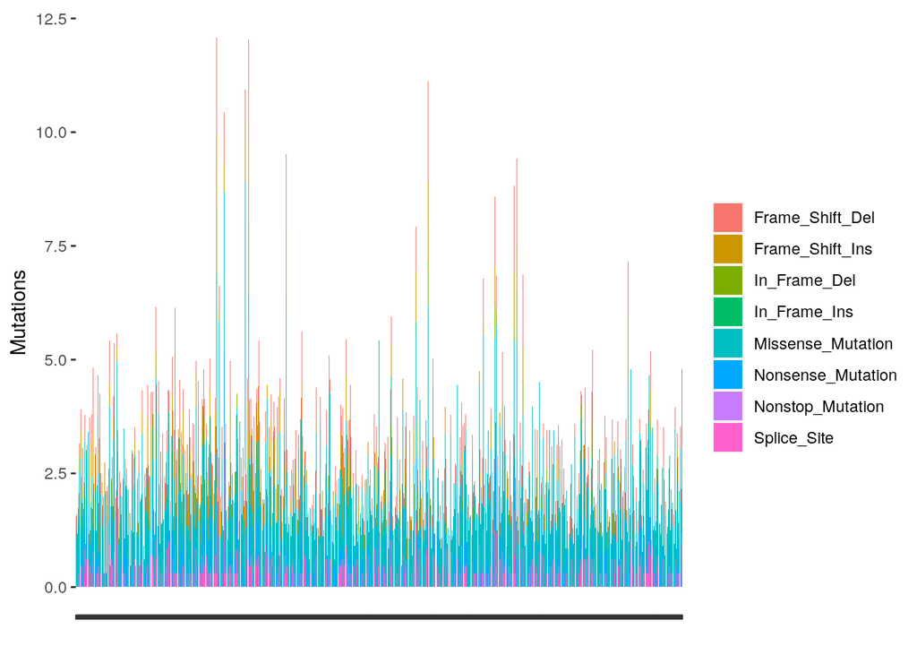

```r
#
ggplot(melt_dat,aes(x=Tumor_Sample_Barcode,y=log10(value),fill=variable))+
  geom_bar(stat='identity',position = 'stack')+
  labs(x="",y="Mutations",fill="")+
  theme(axis.text.x=element_blank())
```

2. Please list top five mutated genes and evaluate the interactions between them
- *TTN* is a huge gene usually with more mutations than others.
- The interactions of gene mutations can be shown in **oncoplot**.

```r
gene_sum <- getGeneSummary(brca)
gene_sum[1:5]
```

```
##        Hugo_Symbol Frame_Shift_Del Frame_Shift_Ins In_Frame_Del In_Frame_Ins
##     1:      PIK3CA               0               2            4            0
##     2:        TP53              40              12            5            0
##     3:         TTN              10               1            2            1
##     4:        CDH1              24              30            0            2
##     5:       GATA3              16              50            0            0
##    ---
## 15232:      ZSCAN9               0               0            0            0
## 15233:      ZSWIM1               0               0            0            0
## 15234:        ZW10               0               0            0            0
## 15235:        ZXDA               0               0            0            0
## 15236:         ZYX               0               0            0            0
```

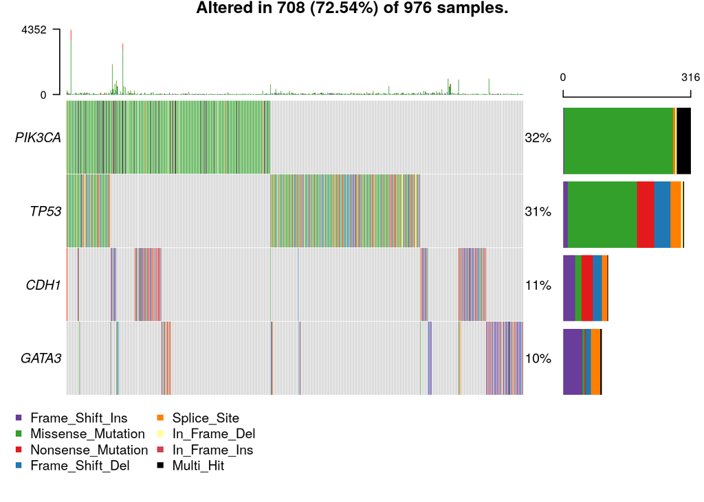

```r
#
oncoplot(brca,top=5,genesToIgnore = "TTN")
```

3. Mutations in PIK3CA is the most common in BRCA dataset. Please plot mutations in a lollipop plot to demonstrate any hotspots. PIK3CA may have hotspots at *E542*, *E545*, and *H1047*.

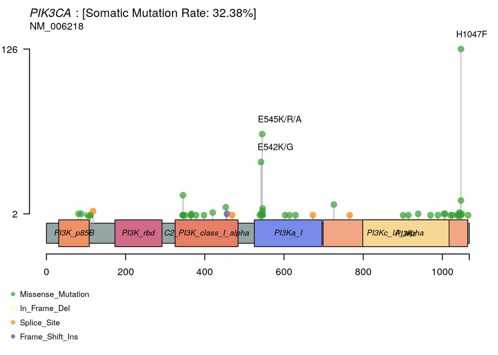

```r
lollipopPlot(brca,gene="PIK3CA",AACol="Protein_Change",labelPos = c(542,545,1047))
```

4. Is there any enriched pathways in BRCA dataset and evaluate the top 3 enriched pathways
- Select enriched pathways: **OncogenicPathways()**
- Display mutations in enriched pathway: **PlotOncogenicPathways()**

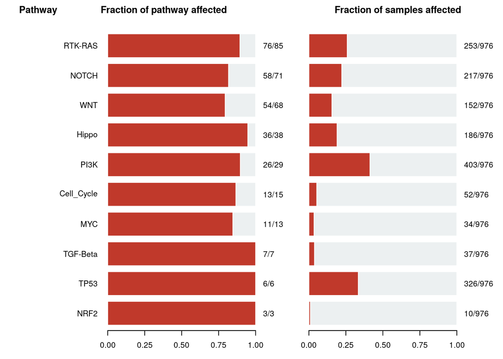

```
##        Pathway  N n_affected_genes fraction_affected Mutated_samples
##  1:       NRF2  3                3         1.0000000              10
##  2:       TP53  6                6         1.0000000             326
##  3:   TGF-Beta  7                7         1.0000000              37
##  4:        MYC 13               11         0.8461538              34
##  5: Cell_Cycle 15               13         0.8666667              52
##  6:       PI3K 29               26         0.8965517             403
##  7:      Hippo 38               36         0.9473684             186
##  8:        WNT 68               54         0.7941176             152
##  9:      NOTCH 71               58         0.8169014             217
## 10:    RTK-RAS 85               76         0.8941176             253
##     Fraction_mutated_samples
##  1:               0.01024590
##  2:               0.33401639
##  3:               0.03790984
##  4:               0.03483607
##  5:               0.05327869
##  6:               0.41290984
##  7:               0.19057377
##  8:               0.15573770
##  9:               0.22233607
## 10:               0.25922131
```

```r
OncogenicPathways(maf = brca)
```

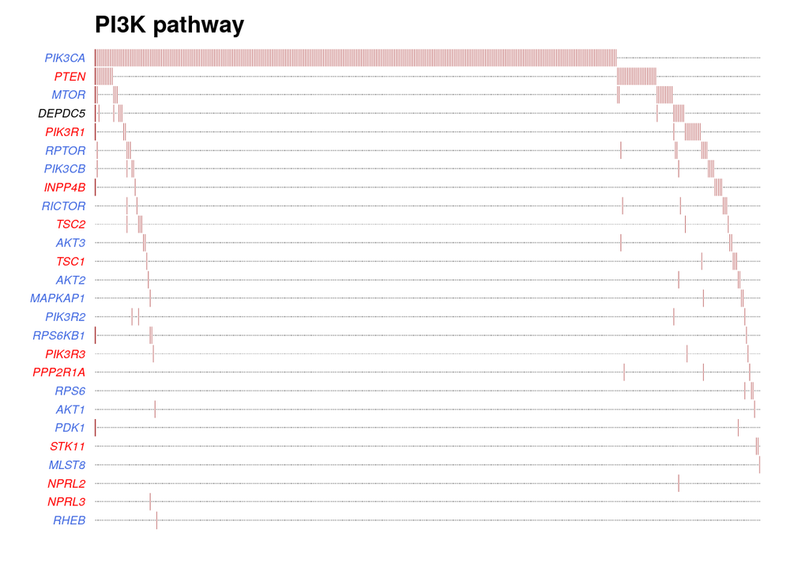

```r
#
PlotOncogenicPathways(maf = brca, pathways = "PI3K")
```

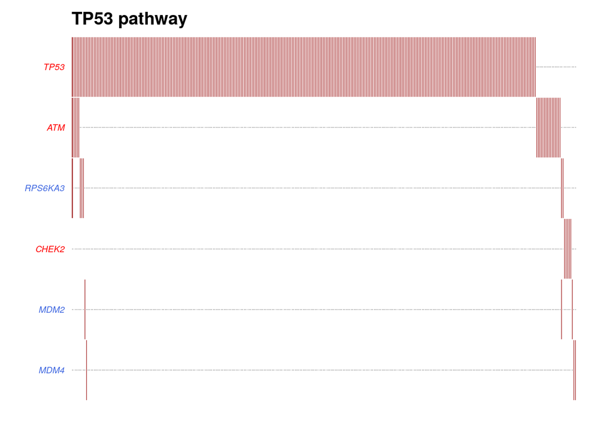

```r
#
PlotOncogenicPathways(maf = brca, pathways = "TP53")
```

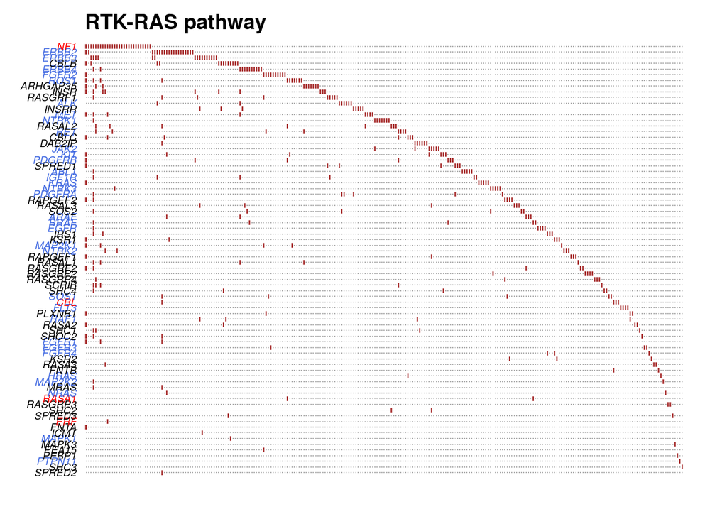

```r
#
PlotOncogenicPathways(maf = brca, pathways = "RTK-RAS")
```

5. Please identify mutational signatures in BRCA dataset
- Make trinucleotide matrix: **trinucleotideMatrix()**
- Estimate number of signatures: ***estimateSignatures()**
- Extract signature: **extractSignatues()**
- Map to COSMIC database and display: **compareSignature()**
- Enrichment analysis: **signatureEnrichment()**

```r
library(BSgenome.Hsapiens.UCSC.hg19, quietly = TRUE)
brca.tnm = trinucleotideMatrix(maf = brca,
                               prefix = 'chr',
                               add = TRUE,
                               ref_genome = "BSgenome.Hsapiens.UCSC.hg19")
```

```
## -Extracting 5' and 3' adjacent bases
## -Extracting +/- 20bp around mutated bases for background C>T estimation
## -Estimating APOBEC enrichment scores
## --Performing one-way Fisher's test for APOBEC enrichment
## ---APOBEC related mutations are enriched in  29.527 % of samples (APOBEC enrichment score > 2 ;  287  of  972  samples)
## -Creating mutation matrix
## --matrix of dimension 975x96
```

```r
#
library('NMF')
brca.sign <- estimateSignatures(mat = brca.tnm,
                                nTry = 10,
                                # pConstant = 0.1,
                                parallel = 1)
```

```
## -Running NMF for 10 ranks
## Compute NMF rank= 2  ... + measures ... OK
## Compute NMF rank= 3  ... + measures ... OK
## Compute NMF rank= 4  ... + measures ... OK
## Compute NMF rank= 5  ... + measures ... OK
## Compute NMF rank= 6  ... + measures ... OK
## Compute NMF rank= 7  ... + measures ... OK
## Compute NMF rank= 8  ... + measures ... OK
## Compute NMF rank= 9  ... + measures ... OK
## Compute NMF rank= 10  ... + measures ... OK
```

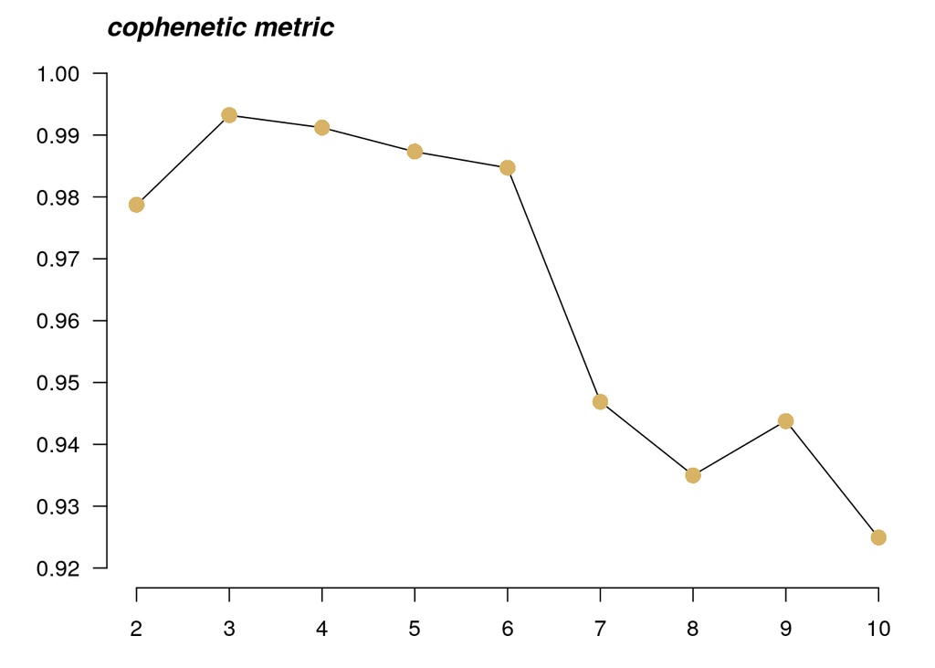

```
## -Finished in 00:23:56 elapsed (00:24:00 cpu)
```

```r
#
brca.sig.ext <- extractSignatures(mat = brca.tnm,
                                  n = 6,
                                  # pConstant = 0.1,
                                  parallel = 1)
```

```
## -Running NMF for factorization rank: 6
```

```
## -Finished in12.9s elapsed (12.9s cpu)
```

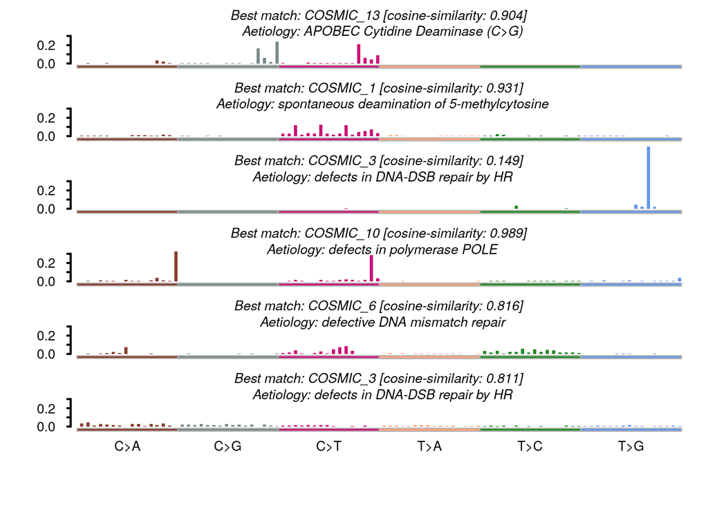

```r
#
plotSignatures(nmfRes = brca.sig.ext,
               title_size = 1.2,
               contributions = FALSE,
               show_title = TRUE,
               sig_db = 'legacy')
```

```r
#
brca.se = signatureEnrichment(maf = brca,
                              sig_res = brca.sig.ext)
```

```
## Running k-means for signature assignment..
```

```
## Performing pairwise and groupwise comparisions..
```

```
## Sample size per factor in Signature:
```

```
##
## Signature_1 Signature_2 Signature_3 Signature_4 Signature_5 Signature_6
##          75         198         126         126         110         221
```

```
## Estimating mutation load and signature exposures..
```

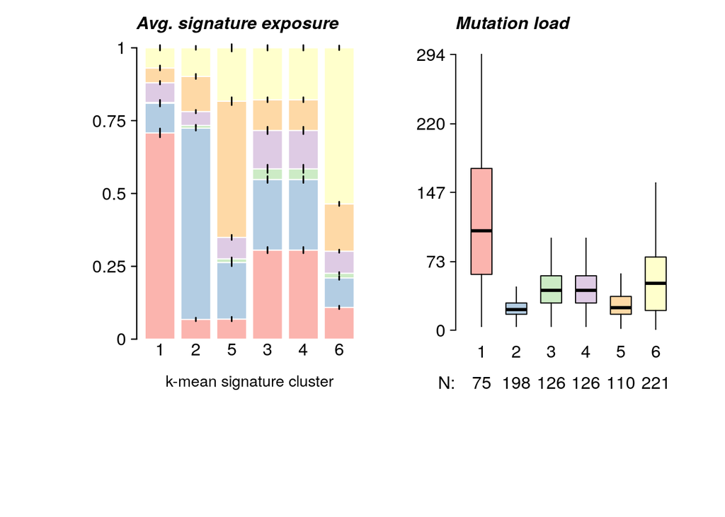